# Practical 3 - Investigating Storm Twitter Data

## Exploring Storm Twitter Data

Aim: To explore, characterize, and interpret the temporal distribution of the tweets.

```python
import os
import pandas as pd
import numpy as np
from sklearn.cluster import KMeans

#os.chdir('/PySources/inm433/03')
df = pd.read_csv('storm_tweets.csv')
df.head()
```

|  | id | Name | X | Y | LONGITUDE | LATITUDE | MESSAGEDATE | USERSCREENNAME | MESSAGETEXT | LOCATION | HASHTAGS | MESSAGETEXT+HASHTAGS | Features | keyword=storm | keyword=wind | keyword=rain | keyword=snow | keyword=hail | keyword=flood | keyword=road | keyword=collapse | keyword=ingury | keyword=disrupt | keyword=forecast | Mask | bad weather (sum) | consequence (sum) | bad weather | consequence |
| --- | --- | --- | --- | --- | --- | --- | --- | --- | --- | --- | --- | --- | --- | --- | --- | --- | --- | --- | --- | --- | --- | --- | --- | --- | --- | --- | --- | --- | --- |
| 0 | 581338551868063744 | storm | 0.071042 | 52.094433 | 0.071042 | 52.094433 | 27/03/2015 06:14:46 | Willis12Pat | Love retirement! My day.. The 7's taping the ... | Fowlmere; England | NaN | Love retirement! My day.. The 7's taping the ... | storm | 1 | 0 | 0 | 0 | 0 | 0 | 0 | 0 | 0 | 0 | 0 | 10000000000 | 1.0 | 0.0 | 1.0 | 0.0 |
| 1 | 581275225955893249 | collapse | -0.210674 | 51.478096 | -0.210674 | 51.478096 | 27/03/2015 02:03:08 | Daiz11 | Fyi if the brightside remix is played in Londo... | Hammersmith; London | NaN | Fyi if the brightside remix is played in Londo... | collapse | 0 | 0 | 0 | 0 | 0 | 0 | 0 | 1 | 0 | 0 | 0 | 1000 | 0.0 | 1.0 | 0.0 | 1.0 |
| 2 | 581312068629954560 | wind | -3.086356 | 53.060090 | -3.086356 | 53.060089 | 27/03/2015 04:29:32 | secondhand_shed | @tonywilliams68 @wrexham strong winds sorry ;i... | Minera; Wales | NaN | @tonywilliams68 @wrexham strong winds sorry ;i... | wind | 0 | 1 | 0 | 0 | 0 | 0 | 0 | 0 | 0 | 0 | 0 | 1000000000 | 1.0 | 0.0 | 1.0 | 0.0 |
| 3 | 581274239308832769 | flood | -1.118795 | 52.617813 | -1.118795 | 52.617813 | 27/03/2015 01:59:12 | DrJonMillett | @Leicester_Merc New street lamp is like living... | Leicester; England | NaN | @Leicester_Merc New street lamp is like living... | flood | 0 | 0 | 0 | 0 | 0 | 1 | 0 | 0 | 0 | 0 | 0 | 100000 | 0.0 | 1.0 | 0.0 | 1.0 |
| 4 | 581330592920444928 | flood | -0.651385 | 51.902275 | -0.651385 | 51.902275 | 27/03/2015 05:43:08 | VirtualJukebox | The Flood by Cheryl Cole is #nowplaying in Any... | East; England | nowplaying | The Flood by Cheryl Cole is #nowplaying in Any... | flood | 0 | 0 | 0 | 0 | 0 | 1 | 0 | 0 | 0 | 0 | 0 | 100000 | 0.0 | 1.0 | 0.0 | 1.0 |

```python
df['msgdate']=pd.to_datetime(df['MESSAGEDATE'], format="%d/%m/%Y %H:%M:%S")
df.msgdate.head()
```

```
0   2015-03-27 06:14:46
1   2015-03-27 02:03:08
2   2015-03-27 04:29:32
3   2015-03-27 01:59:12
4   2015-03-27 05:43:08
Name: msgdate, dtype: datetime64[ns]
```

```python
df.msgdate.min()
```

```
Timestamp('2015-03-27 00:05:49')
```

```python
#df.msgdate.min().date()
df['msgdate_h']=(pd.to_datetime(df.msgdate)-pd.to_datetime(df.msgdate.min().date())).astype('int64')/1000000000/3600
#sort ascending by time
df.sort_values(by='msgdate_h').head()
```

|  | id | Name | X | Y | LONGITUDE | LATITUDE | MESSAGEDATE | USERSCREENNAME | MESSAGETEXT | LOCATION | HASHTAGS | MESSAGETEXT+HASHTAGS | Features | keyword=storm | keyword=wind | keyword=rain | keyword=snow | keyword=hail | keyword=flood | keyword=road | keyword=collapse | keyword=ingury | keyword=disrupt | keyword=forecast | Mask | bad weather (sum) | consequence (sum) | bad weather | consequence | … |
| --- | --- | --- | --- | --- | --- | --- | --- | --- | --- | --- | --- | --- | --- | --- | --- | --- | --- | --- | --- | --- | --- | --- | --- | --- | --- | --- | --- | --- | --- | --- |
| 18 | 581245702476574720 | collapse;ingury | -6.481964 | 53.318516 | -6.481964 | 53.318516 | 27/03/2015 00:05:49 | Watersun555 | Dozen Injured In New York Building Collapse ht... | South Dublin; Ireland | NaN | Dozen Injured In New York Building Collapse ht... | collapse;ingury | 0 | 0 | 0 | 0 | 0 | 0 | 0 | 1 | 1 | 0 | 0 | 1100 | 0.0 | 2.0 | 0.0 | 1.0 | … |
| 16 | 581245871326629889 | flood | -0.083102 | 51.540160 | -0.083102 | 51.540161 | 27/03/2015 00:06:29 | KeishaFrancis | FLOOD OUT!!! | Hackney; London | NaN | FLOOD OUT!!!; | flood | 0 | 0 | 0 | 0 | 0 | 1 | 0 | 0 | 0 | 0 | 0 | 100000 | 0.0 | 1.0 | 0.0 | 1.0 | … |
| 17 | 581245981267722241 | ingury | -6.481935 | 53.318527 | -6.481935 | 53.318527 | 27/03/2015 00:06:55 | Watersun555 | 30 Injured As Coach Overturns In Scotland http... | South Dublin; Ireland | NaN | 30 Injured As Coach Overturns In Scotland http... | ingury | 0 | 0 | 0 | 0 | 0 | 0 | 0 | 0 | 1 | 0 | 0 | 100 | 0.0 | 1.0 | 0.0 | 1.0 | … |
| 7 | 581268046955806720 | storm | -1.584887 | 52.778570 | -1.584887 | 52.778568 | 27/03/2015 01:34:36 | _katiegreen__ | stormzy / mievado | Swadlincote; England | NaN | stormzy / mievado; | storm | 1 | 0 | 0 | 0 | 0 | 0 | 0 | 0 | 0 | 0 | 0 | 10000000000 | 1.0 | 0.0 | 1.0 | 0.0 | … |
| 9 | 581270572723634176 | forecast | 0.252533 | 51.511170 | 0.252533 | 51.511169 | 27/03/2015 01:44:38 | TheMockneyRebel | Guardian/ICM survey puts Labour in line to gai... | Aveley; England | NaN | Guardian/ICM survey puts Labour in line to gai... | forecast | 0 | 0 | 0 | 0 | 0 | 0 | 0 | 0 | 0 | 0 | 1 | 1 | 0.0 | 0.0 | 0.0 | 0.0 | … |

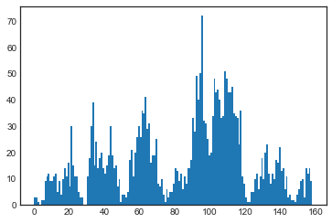

```python
%matplotlib inline
import matplotlib.pyplot as plt
plt.style.use('seaborn-white')
plt.hist(df.msgdate_h, bins=range(0,df.msgdate_h.max().round().astype('int64')+1,1))
```

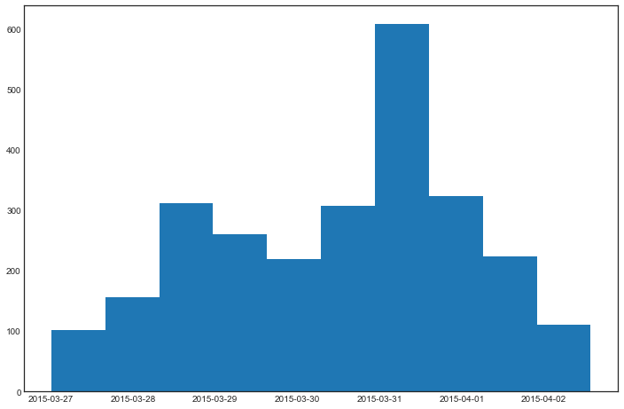

```python
#Exploring the temporal distrubition of tweets
#create a time historgram by day
%matplotlib inline
import matplotlib.pyplot as plt
plt.style.use('seaborn-white')
plt.figure(figsize=(12,8))
plt.hist(df.msgdate)
```

This plot helps us see when the majority of tweets occured, using the more comprehendable date-time expression

[output not shown]

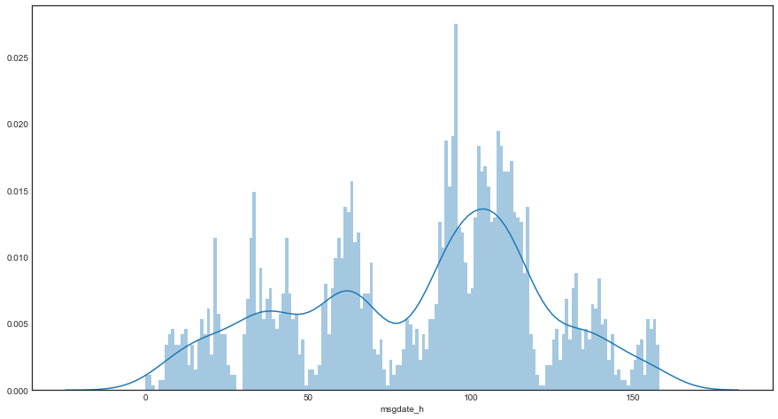

```python
#Using Seaborn to make nicer plots + using KDE (kernal density estimate)
import seaborn as sns
plt.figure(figsize=(15,8))
sns.distplot(df.msgdate_h, bins=range(0,df.msgdate_h.max().round().astype('int64')+1,1));
```

## How do tweets develop over time?

I am interested to know if tweets with keywords follow different trends, so I want to plot them on one chart to see the distribution:

```python
#how do tweets develop overtime?

df_fo = df['keyword=forecast'] == 1
df_forecast = df[df_fo]
df_r = df['keyword=rain'] == 1
df_rain = df[df_r]
df_c = df['keyword=collapse'] == 1
df_collapse = df[df_c]
df_w = df['keyword=wind'] == 1
df_wind = df[df_w]
```

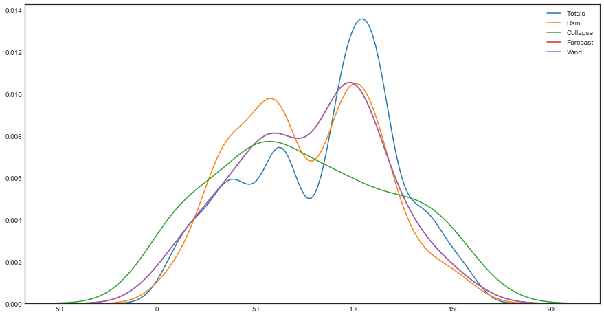

```python
#Plotting different tweet types on same distribution
plt.figure(figsize=(15,8))
sns.kdeplot(df.msgdate_h, label="Totals")
sns.kdeplot(df_rain.msgdate_h, label="Rain")
sns.kdeplot(df_collapse.msgdate_h, label="Collapse")
sns.kdeplot(df_forecast.msgdate_h, label="Forecast")
sns.kdeplot(df_forecast.msgdate_h, label="Wind")
plt.legend();
```

Perhaps if the data was a wider sample, and included tweets before the storm we might see trends develop over time.

```python
#adapted from
#https://stackoverflow.com/questions/42756934/how-to-plot-lat-and-long-from-pandas-dataframe-on-folium-map-group-by-some-label
import folium
import os
import pandas as pd
import numpy as np
```

```python
#os.chdir('/PySources/inm433/03')
df = pd.read_csv('storm_tweets.csv')
pd.set_option('display.max_columns', None)
df.tail()
```

|  | id | Name | X | Y | LONGITUDE | LATITUDE | MESSAGEDATE | USERSCREENNAME | MESSAGETEXT | LOCATION | HASHTAGS | MESSAGETEXT+HASHTAGS | Features | keyword=storm | keyword=wind | keyword=rain | keyword=snow | keyword=hail | keyword=flood | keyword=road | keyword=collapse | keyword=ingury | keyword=disrupt | keyword=forecast | Mask | bad weather (sum) | consequence (sum) | bad weather | consequence |
| --- | --- | --- | --- | --- | --- | --- | --- | --- | --- | --- | --- | --- | --- | --- | --- | --- | --- | --- | --- | --- | --- | --- | --- | --- | --- | --- | --- | --- | --- |
| 2615 | 583602691814858753 | storm | -0.431765 | 52.152850 | -0.431765 | 52.152851 | 02/04/2015 12:11:39 | h_aulsberry | Stormz is my fav | Bedford; England | NaN | Stormz is my fav; | storm | 1 | 0 | 0 | 0 | 0 | 0 | 0 | 0 | 0 | 0 | 0 | 10000000000 | 1.0 | 0.0 | 1.0 | 0.0 |
| 2616 | 583607718394650625 | storm | -5.837416 | 54.597523 | -5.837416 | 54.597523 | 02/04/2015 12:31:37 | oocasbahoo | Run fatty run! Couch to 5k day 2! #diet #fitne... | Northern Ireland; United Kingdom | diet fitness health | Run fatty run! Couch to 5k day 2! #diet #fitne... | storm | 1 | 0 | 0 | 0 | 0 | 0 | 0 | 0 | 0 | 0 | 0 | 10000000000 | 1.0 | 0.0 | 1.0 | 0.0 |
| 2617 | 583603917596057600 | disrupt | -4.165804 | 55.762030 | -4.165804 | 55.762032 | 02/04/2015 12:16:31 | baxter_wa | @ThreeUK voicemail that seriously disrupts wor... | East Kilbride; Scotland | putdisabilityfirst | @ThreeUK voicemail that seriously disrupts wor... | disrupt | 0 | 0 | 0 | 0 | 0 | 0 | 0 | 0 | 0 | 1 | 0 | 10 | 0.0 | 1.0 | 0.0 | 1.0 |
| 2618 | 583387218229796864 | storm | -3.203806 | 51.480530 | -3.203806 | 51.480530 | 01/04/2015 21:55:26 | KaiOwenFanpage | #PhotoOfTheDay A great photo of @KaiKaiOwen f... | Cardiff; Wales | PhotoOfTheDay | #PhotoOfTheDay A great photo of @KaiKaiOwen f... | storm | 1 | 0 | 0 | 0 | 0 | 0 | 0 | 0 | 0 | 0 | 0 | 10000000000 | 1.0 | 0.0 | 1.0 | 0.0 |
| 2619 | 583607170756927488 | collapse | -1.780078 | 50.963432 | -1.780078 | 50.963432 | 02/04/2015 12:29:27 | bassmadman | @Peston: We're earning 17% less per hour than ... | Breamore; England | NaN | @Peston: We're earning 17% less per hour than ... | collapse | 0 | 0 | 0 | 0 | 0 | 0 | 0 | 1 | 0 | 0 | 0 | 1000 | 0.0 | 1.0 | 0.0 | 1.0 |

```python
xmm=(df.X.min()+df.X.max())/2
ymm=(df.Y.min()+df.Y.max())/2
map = folium.Map(location=[ymm,xmm], zoom_start=5)
df.apply(lambda row:folium.CircleMarker(location=[row["Y"], row["X"]],
                                              radius=3) #fill_color=colors[row['Class']])
                                             .add_to(map), axis=1)
map
```

[interactive chart not shown]

## We want to investigate distribution, so a heatmap could work!

```python
from folium.plugins import HeatMap
```

```python
xmm=(df.X.min()+df.X.max())/2
ymm=(df.Y.min()+df.Y.max())/2

hmap = folium.Map(location=[ymm,xmm], zoom_start=5)

hm_wide = HeatMap(list(zip(df.LATITUDE.values, df.LONGITUDE.values)),
                   min_opacity=0.2,
                   radius=17, blur=15,
                   max_zoom=1,
                 )

hmap.add_child(hm_wide)
```

[interactive chart not shown]

So this isn't very helpful...

Let's try altering the heatmap values:

```python
xmm=(df.X.min()+df.X.max())/2
ymm=(df.Y.min()+df.Y.max())/2

hmap = folium.Map(location=[ymm,xmm], zoom_start=6)

hm_wide = HeatMap(list(zip(df.LATITUDE.values, df.LONGITUDE.values)),
                   min_opacity=0.2,
                   radius=5, blur=10, #Adjusting the radius will make areas more distict, and reducing blur will make map clearer!
                   max_zoom=1,
                 )

hmap.add_child(hm_wide)
```

[interactive chart not shown]

Fairly unsurprisingly, the majority of tweets are centred around the big cities (London, Manchester, Norwich, Dublin, Edinburgh & Newcastle).

It's quite difficult to distiguish the intensity between areas where there are a high number of tweets, altering the colours could help...

```python
xmm=(df.X.min()+df.X.max())/2
ymm=(df.Y.min()+df.Y.max())/2

hmap = folium.Map(location=[ymm,xmm], zoom_start=7)

hm_wide = HeatMap(list(zip(df.LATITUDE.values, df.LONGITUDE.values)),
                   min_opacity=0.2,
                   radius=7, blur=10,
                   max_zoom=1, gradient={.6: 'blue', .9: 'orange', 1: 'red'})


hmap.add_child(hm_wide)
```

[interactive chart not shown]

Not much better, so we can use a Marker Cluster which will aggregate the tweets for an area, dependent on the zoom - this can help distinguish between dense areas.

```python
from folium.plugins import MarkerCluster
map2 = folium.Map(location=[ymm,xmm], zoom_start=6)
marker_cluster = folium.plugins.MarkerCluster().add_to(map2)
df.apply(lambda row:folium.Marker(location=[row["Y"], row["X"]])
                                             .add_to(marker_cluster), axis=1)
map2

## Click on the circles to zoom in and interact!
```

[interactive chart not shown]